# Proyecto 3 – Agrupación de datos sobre obesidad

- David Leonardo Moreno Bedoya
- Jesus Santiago Amado Montaña
- Yodid Jair Cárdenas Rodríguez

#### Explicación de problema

El conjunto de datos que vamos a tratar se estima los niveles de obesidad las personas de los paises México, Perú y Colombia, basándose en sus hábitos alimenticios y condición física. El archivo tiene 17 atributos y 2111 registros, etiquetados con la variable de clase *NObesity*, que clasifica los datos en Insuficiencia de Peso, Peso Normal, Sobrepeso Nivel I, Sobrepeso Nivel II, Obesidad Tipo I, Obesidad Tipo II y Obesidad Tipo III. El 77% de los datos fue generado de forma sintética utilizando la herramienta Weka y el filtro SMOTE, mientras que el 23% se recopiló directamente de los usuarios a través de una plataforma web.

```python
## Librerias para el ejercicio
import pandas as pd
import numpy as np
import seaborn as sns
import matplotlib.pyplot as plt
from sklearn.cluster import KMeans
from sklearn.decomposition import PCA
from sklearn.datasets import make_blobs
from sklearn.preprocessing import StandardScaler
```

### Descripción de variables

```python
# Creación de un diccionario con las listas de igual longitud
data = {
    'Variable': ['Gender', 'Age', 'Height', 'Weight', 'family_history_with_overweight', 'FAVC', 'FCVC', 'NCP', 'CAEC', 'SMOKE', 'CH2O', 'SCC', 'FAF', 'TUE', 'CALC', 'MTRANS', 'NObeyesdad'],
    'Descripción': ['Género del individuo', 'Edad del individuo', 'Altura del individuo', 'Peso del individuo', 'Historia familiar con sobrepeso', 'Frecuencia de consumo de alimentos altos en calorías', 'Frecuencia de consumo de vegetales', 'Número de comidas principales', 'Frecuencia de consumo de comida entre comidas', 'Hábito de fumar', 'Consumo de agua diaria', 'Monitorización del consumo calórico', 'Frecuencia de actividad física', 'Tiempo viendo televisión', 'Consumo de alcohol', 'Medio de transporte', 'Nivel de obesidad'],
    'Tipo de Dato': ['Categórico', 'Numérico', 'Numérico', 'Numérico', 'Categórico', 'Categórico', 'Categórico', 'Numérico', 'Categórico', 'Categórico', 'Numérico', 'Categórico', 'Numérico', 'Numérico', 'Categórico', 'Categórico', 'Categórico']
}

# Conversión del diccionario a un DataFrame
df = pd.DataFrame(data)

# Mostrar la tabla
print(df)
```

```
                          Variable  \
0                           Gender
1                              Age
2                           Height
3                           Weight
4   family_history_with_overweight
5                             FAVC
6                             FCVC
7                              NCP
8                             CAEC
9                            SMOKE
10                            CH2O
11                             SCC
12                             FAF
13                             TUE
```

[output cut: 22 more lines]

##### Exploración con metodo "Object" de Pandas

count: El número de observaciones no nulas. unique: El número de valores únicos. top_: El valor que ocurre con más frecuencia (moda). freq: La frecuencia del valor más común.

##### Exploración con metodo "Number" de Pandas

count: El número de observaciones no nulas.

mean: La media de las observaciones

std: La desviación estándar de las observacions.

min: El valor mínimo de las observacines.

25%: El percentil 25, también conocido como el primer cartil.

50%: El percentil 50, también conocido como lamediana.

75%: El percentil 75, también conocido como el tercr cuartil.

max: El valor máximo de las observaciones.

```python
df = pd.read_csv('ObesityDataSet_raw_and_data_sinthetic.csv')
df.describe(include='object')
```

|  | Gender | family_history_with_overweight | FAVC | CAEC | SMOKE | SCC | CALC | MTRANS | NObeyesdad |
| --- | --- | --- | --- | --- | --- | --- | --- | --- | --- |
| count | 2111 | 2111 | 2111 | 2111 | 2111 | 2111 | 2111 | 2111 | 2111 |
| unique | 2 | 2 | 2 | 4 | 2 | 2 | 4 | 5 | 7 |
| top | Male | yes | yes | Sometimes | no | no | Sometimes | Public_Transportation | Obesity_Type_I |
| freq | 1068 | 1726 | 1866 | 1765 | 2067 | 2015 | 1401 | 1580 | 351 |

```python
df.describe(include='number')
```

|  | Age | Height | Weight | FCVC | NCP | CH2O | FAF | TUE |
| --- | --- | --- | --- | --- | --- | --- | --- | --- |
| count | 2111.000000 | 2111.000000 | 2111.000000 | 2111.000000 | 2111.000000 | 2111.000000 | 2111.000000 | 2111.000000 |
| mean | 24.312600 | 1.701677 | 86.586058 | 2.419043 | 2.685628 | 2.008011 | 1.010298 | 0.657866 |
| std | 6.345968 | 0.093305 | 26.191172 | 0.533927 | 0.778039 | 0.612953 | 0.850592 | 0.608927 |
| min | 14.000000 | 1.450000 | 39.000000 | 1.000000 | 1.000000 | 1.000000 | 0.000000 | 0.000000 |
| 25% | 19.947192 | 1.630000 | 65.473343 | 2.000000 | 2.658738 | 1.584812 | 0.124505 | 0.000000 |
| 50% | 22.777890 | 1.700499 | 83.000000 | 2.385502 | 3.000000 | 2.000000 | 1.000000 | 0.625350 |
| 75% | 26.000000 | 1.768464 | 107.430682 | 3.000000 | 3.000000 | 2.477420 | 1.666678 | 1.000000 |
| max | 61.000000 | 1.980000 | 173.000000 | 3.000000 | 4.000000 | 3.000000 | 3.000000 | 2.000000 |

```python
# Cargar el archivo CSV
df = pd.read_csv('ObesityDataSet_raw_and_data_sinthetic.csv')

# Determinar la cantidad de variables (columnas) y registros (filas)
num_variables = df.shape[1]
num_registros = df.shape[0]

# Identificar variables numéricas y cualitativas
variables_numericas = df.select_dtypes(include=['int64', 'float64']).columns.tolist()
variables_categoricas = df.select_dtypes(include=['object', 'category']).columns.tolist()

# Resumen de la información
resumen = {
    'Cantidad de Variables': num_variables,
    'Cantidad de Registros': num_registros,
    'Variables Numéricas': variables_numericas,
    'Variables Categoricas': variables_categoricas
}

print("Resumen de la Información del DataFrame:")
for key, value in resumen.items():
    print(f"{key}: {value}")
```

```
Resumen de la Información del DataFrame:
Cantidad de Variables: 17
Cantidad de Registros: 2111
Variables Numéricas: ['Age', 'Height', 'Weight', 'FCVC', 'NCP', 'CH2O', 'FAF', 'TUE']
Variables Categoricas: ['Gender', 'family_history_with_overweight', 'FAVC', 'CAEC', 'SMOKE', 'SCC', 'CALC', 'MTRANS', 'NObeyesdad']
```

```python
## Nulos
df.isnull().sum()
```

```
Gender                            0
Age                               0
Height                            0
Weight                            0
family_history_with_overweight    0
FAVC                              0
FCVC                              0
NCP                               0
CAEC                              0
SMOKE                             0
CH2O                              0
SCC                               0
FAF                               0
TUE                               0
CALC                              0
MTRANS                            0
NObeyesdad                        0
dtype: int64
```

###### Se revisa las variales y no se encuentra nulos.

```
Index(['Gender', 'Age', 'Height', 'Weight', 'family_history_with_overweight',
       'FAVC', 'FCVC', 'NCP', 'CAEC', 'SMOKE', 'CH2O', 'SCC', 'FAF', 'TUE',
       'CALC', 'MTRANS', 'NObeyesdad'],
      dtype='object')
```

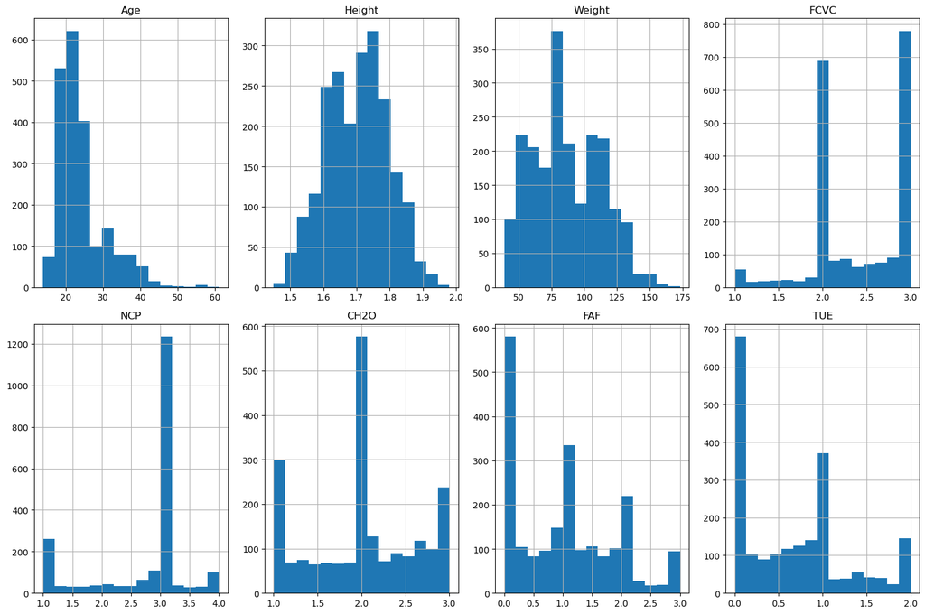

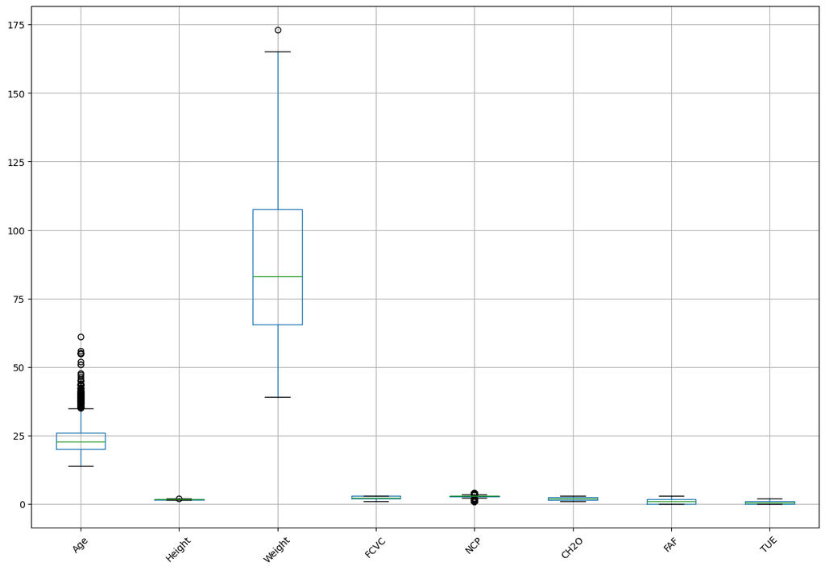

```python
# Mostrar las columnas del DataFrame
print(df.columns)

# variables numéricas
variables_numericas = ['Age', 'Height', 'Weight', 'FCVC', 'NCP', 'CH2O', 'FAF', 'TUE']

# Histograma de las variables numéricas
df[variables_numericas].hist(bins=15, figsize=(15, 10), layout=(2, 4))
plt.tight_layout()
plt.show()

# Diagramas de caja para las variables numéricas
plt.figure(figsize=(15, 10))
df[variables_numericas].boxplot()
plt.xticks(rotation=45)
plt.show()
```

## Planteamiento de Hipótesis

A continuación, se presentan dos hipótesis iniciales relacionadas con los patrones de obesidad y su relación con los hábitos y características demográficas de los individuos:

- **Hipótesis 1:** Las personas que reportan altos niveles de consumo de alimentos altos en calorías (como el consumo frecuente de comidas hipercalóricas, `FAVC`) tienden a presentar mayores niveles de obesidad. También se espera que el consumo de vegetales (`FCVC`), el número de comidas principales (`NCP`), y los patrones de comida emocional (`CAEC`) estén relacionados con el índice de masa corporal.
- **Hipótesis 2:** Los niveles de obesidad varían significativamente según la edad (`Age`) y el género (`Gender`). Es probable que ciertas edades y géneros presenten una predisposición más alta a la obesidad debido a factores metabólicos, hormonales y cambios en los niveles de actividad física.

```python
# Estadísticas descriptivas de variables relevantes para la Hipótesis 1
favc_stats = df['FAVC'].value_counts()  # Consumo frecuente de alimentos hipercalóricos
fcvc_stats = df['FCVC'].describe()      # Consumo de vegetales
ncp_stats = df['NCP'].describe()         # Número de comidas principales
caec_stats = df['CAEC'].value_counts()   # Comida emocional
```

```python
# Hipótesis 2: Distribución de obesidad según edad y género
age_stats = df['Age'].describe()
gender_counts = df['Gender'].value_counts()
obesity_levels_by_gender = df.groupby('Gender')['NObeyesdad'].value_counts()
```

```python
# Mostrar resultados
print("Distribución de Consumo Frecuente de Alimentos Calóricos (FAVC):")
print(favc_stats)
print("\nEstadísticas de Consumo de Vegetales (FCVC):")
print(fcvc_stats)
print("\nEstadísticas de Número de Comidas Principales (NCP):")
print(ncp_stats)
print("\nDistribución de Comida Emocional (CAEC):")
print(caec_stats)
print("\nDistribución de Edad:")
print(age_stats)
print("\nDistribución de Género:")
print(gender_counts)
print("\nNiveles de Obesidad por Género:")
print(obesity_levels_by_gender)
```

```
Distribución de Consumo Frecuente de Alimentos Calóricos (FAVC):
FAVC
yes    1866
no      245
Name: count, dtype: int64

Estadísticas de Consumo de Vegetales (FCVC):
count    2111.000000
mean        2.419043
std         0.533927
min         1.000000
25%         2.000000
50%         2.385502
75%         3.000000
max         3.000000
Name: FCVC, dtype: float64

Estadísticas de Número de Comidas Principales (NCP):
count    2111.000000
mean        2.685628
std         0.778039
min         1.000000
25%         2.658738
50%         3.000000
75%         3.000000
max         4.000000
Name: NCP, dtype: float64

Distribución de Comida Emocional (CAEC):
CAEC
Sometimes     1765
Frequently     242
Always          53
no              51
Name: count, dtype: int64

Distribución de Edad:
count    2111.000000
mean       24.312600
std         6.345968
```

[output cut: 15 more lines]

```
Female  Obesity_Type_III       323
        Insufficient_Weight    173
        Obesity_Type_I         156
        Overweight_Level_I     145
        Normal_Weight          141
        Overweight_Level_II    103
        Obesity_Type_II          2
Male    Obesity_Type_II        295
        Obesity_Type_I         195
        Overweight_Level_II    187
        Normal_Weight          146
        Overweight_Level_I     145
        Insufficient_Weight     99
        Obesity_Type_III         1
Name: count, dtype: int64
```

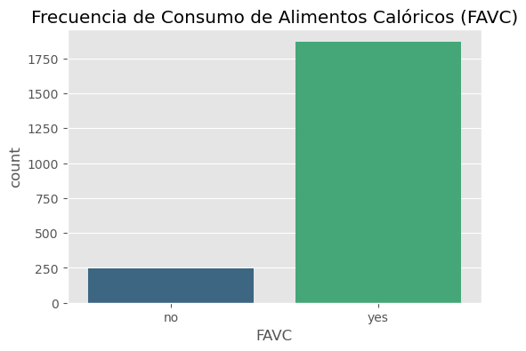

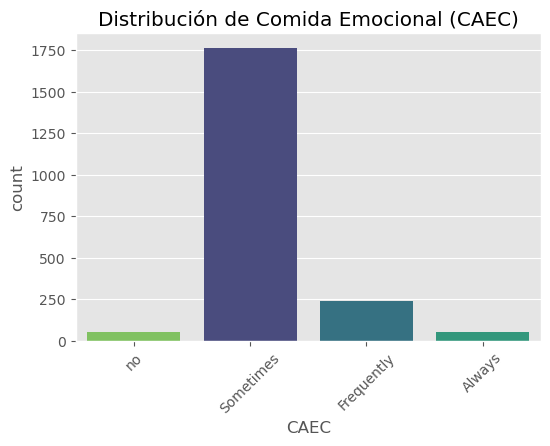

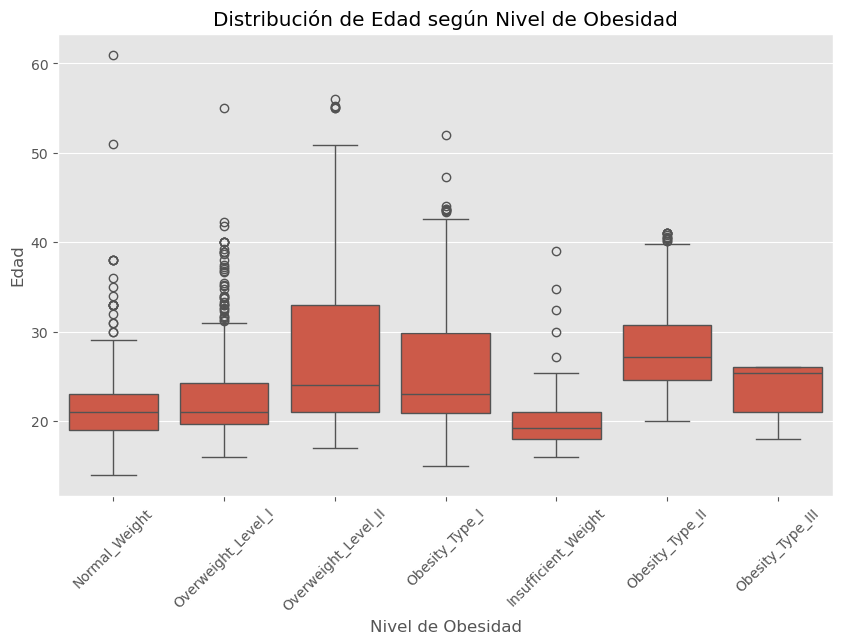

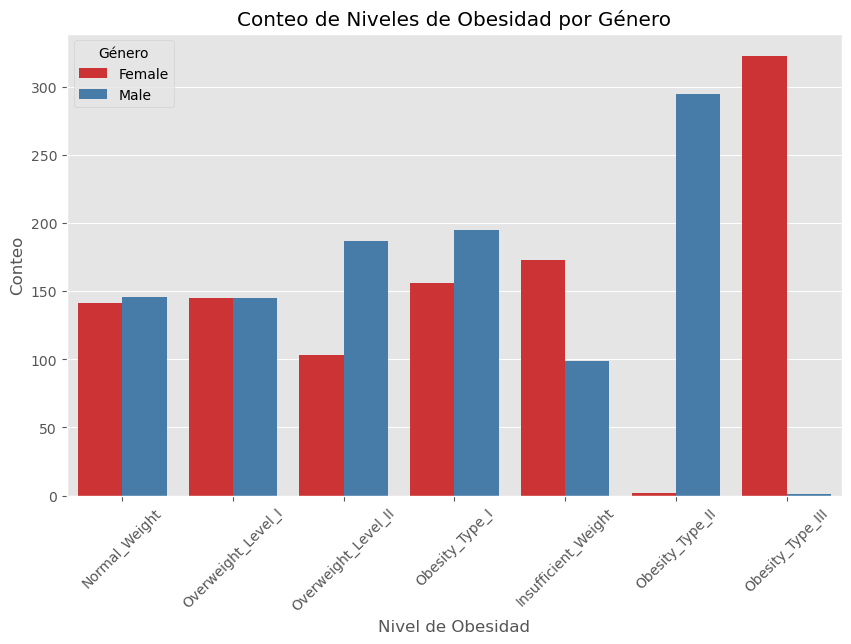

```python
## Visualizacion

# Configuración de estilo
plt.style.use('ggplot')

# 1. Distribución de Consumo de Alimentos Calóricos (FAVC)
plt.figure(figsize=(6, 4))
sns.countplot(data=df, x='FAVC', hue='FAVC', palette='viridis', legend=False)
plt.title('Frecuencia de Consumo de Alimentos Calóricos (FAVC)')
plt.xlabel('FAVC')
plt.show()

# 2. Distribución de Comida Emocional (CAEC)
plt.figure(figsize=(6, 4))
sns.countplot(data=df, x='CAEC', hue='CAEC', order=['no', 'Sometimes', 'Frequently', 'Always'], palette='viridis', legend=False)
plt.title('Distribución de Comida Emocional (CAEC)')
plt.xlabel('CAEC')
plt.xticks(rotation=45)
plt.show()

# 3. Boxplot de Edad según el Nivel de Obesidad (NObeyesdad)
plt.figure(figsize=(10, 6))
sns.boxplot(data=df, x='NObeyesdad', y='Age')
plt.title('Distribución de Edad según Nivel de Obesidad')
plt.xticks(rotation=45)
plt.xlabel('Nivel de Obesidad')
plt.ylabel('Edad')
plt.show()

# 4. Conteo de Niveles de Obesidad por Género
plt.figure(figsize=(10, 6))
sns.countplot(data=df, x='NObeyesdad', hue='Gender', palette='Set1')
plt.title('Conteo de Niveles de Obesidad por Género')
plt.xticks(rotation=45)
plt.xlabel('Nivel de Obesidad')
plt.ylabel('Conteo')
plt.legend(title='Género')
plt.show()
```

#### Visualización de Datos y Reducción de Dimensionalidad

Usa técnicas como PCA (Análisis de Componentes Principales) para reducir la dimensionalidad y visualizar los datos:

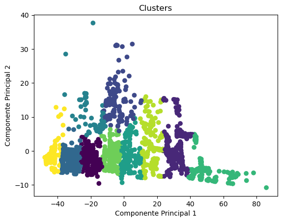

```python
# Selección de variables cuantitativas
X = df[variables_numericas]

# Reducción de dimensionalidad usando PCA
pca = PCA(n_components=2)
X_pca = pca.fit_transform(X)

# kmeans ajustado
kmeans = KMeans(n_clusters=10, random_state=42)  # Ajusta el número de clusters según tu análisis
kmeans.fit(X)
labels = kmeans.labels_

# Visualización de los datos en el plano cartesiano
plt.scatter(X_pca[:, 0], X_pca[:, 1], c=labels, cmap='viridis')
plt.title('Clusters')
plt.xlabel('Componente Principal 1')
plt.ylabel('Componente Principal 2')
plt.show()
```

##### Determinación de los Clusteres usando el método del codo

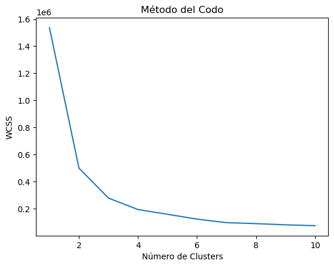

```python
# Fijar una semilla
np.random.seed(42)

# Selección de variables cuantitativas
X = df[variables_numericas]

# Determinación del número de grupos usando el método del codo
wcss = []
for i in range(1, 11):
    kmeans = KMeans(n_clusters=i, random_state=42)
    kmeans.fit(X)
    wcss.append(kmeans.inertia_)


plt.plot(range(1, 11), wcss)
plt.title('Método del Codo')
plt.xlabel('Número de Clusters')
plt.ylabel('WCSS')
plt.show()
```

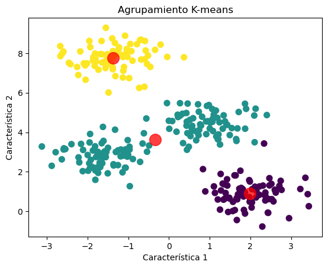

```python
# Generar datos
X, _ = make_blobs(n_samples=300, centers=4, cluster_std=0.60, random_state=0)

# Aplicar K-means
kmeans = KMeans(n_clusters=3)
kmeans.fit(X)
y_kmeans = kmeans.predict(X)

# Graficar los puntos y los centroides
plt.scatter(X[:, 0], X[:, 1], c=y_kmeans, s=50, cmap='viridis')
centers = kmeans.cluster_centers_
plt.scatter(centers[:, 0], centers[:, 1], c='red', s=200, alpha=0.75)
plt.title('Agrupamiento K-means')
plt.xlabel('Característica 1')
plt.ylabel('Característica 2')
plt.show()
```